# Regression Model week-4 project

## Inference

```r
t_test<- t.test(mpg ~ am, mtcars)
t_test
```

```
##
##  Welch Two Sample t-test
##
## data:  mpg by am
## t = -3.7671, df = 18.332, p-value = 0.001374
## alternative hypothesis: true difference in means is not equal to 0
## 95 percent confidence interval:
##  -11.280194  -3.209684
## sample estimates:
## mean in group Automatic    mean in group Manual
##                17.14737                24.39231
```

From the result we can say that, t_test **Reject** the **Null hypothesis** that there is a difference between transmission mean is equal to 0. i.e(p_value=0.001374)

And, the difference between the estimates of the two transmission is **7.245** MPG(miles per gallon), which tells the **Manual Transmission Vehicles** is **better** than Automatic Transmission Vehicles.

## Regression Analysis

### Fit the linear regression model for the Whole data.

```r
fit<- lm(mpg~. , mtcars)
summary(fit)$coeff
```

```
##                Estimate  Std. Error     t value   Pr(>|t|)
## (Intercept) 23.87913244 20.06582026  1.19004018 0.25252548
## cyl6        -2.64869528  3.04089041 -0.87102622 0.39746642
## cyl8        -0.33616298  7.15953951 -0.04695316 0.96317000
## disp         0.03554632  0.03189920  1.11433290 0.28267339
## hp          -0.07050683  0.03942556 -1.78835344 0.09393155
## drat         1.18283018  2.48348458  0.47627845 0.64073922
## wt          -4.52977584  2.53874584 -1.78425732 0.09461859
## qsec         0.36784482  0.93539569  0.39325050 0.69966720
## vs1          1.93085054  2.87125777  0.67247551 0.51150791
## amManual     1.21211570  3.21354514  0.37718957 0.71131573
## gear4        1.11435494  3.79951726  0.29328856 0.77332027
## gear5        2.52839599  3.73635801  0.67670068 0.50889747
## carb2       -0.97935432  2.31797446 -0.42250436 0.67865093
## carb3        2.99963875  4.29354611  0.69863900 0.49546781
## carb4        1.09142288  4.44961992  0.24528452 0.80956031
## carb6        4.47756921  6.38406242  0.70136677 0.49381268
## carb8        7.25041126  8.36056638  0.86721532 0.39948495
```

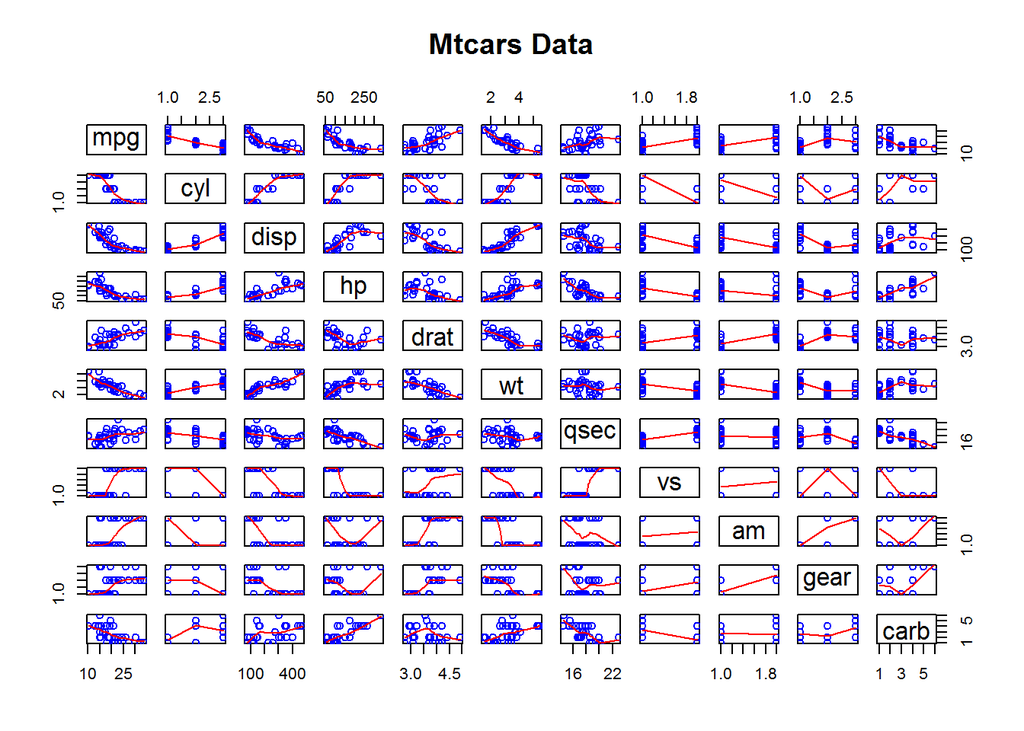

```r
pairs(mpg~. ,panel= panel.smooth, main="Mtcars Data", col=4, mtcars)
```

In this, we notice that none of the coefficient of the variables have p-value is less than 0.05, so we cannot say that there is which variable is Statistically Significant.To observe the intial relationship between the variables we plot scatterplot by plotting each variables against all other variables which tells the correlation between them.